# 1 Housekeeping

rm(list=ls()) # remove everything currently held in the R memory

# 2 t-tests in R

Template file on how to perform t-tests in R. This file is a direct follow-on from the podcast “Intro to R lesson 3 - reading in data” and its associated script and data

# 3 Enter or read in your data from a file

read in data from our CSV file This is a comma separated file

```r
mydata <- read.table("finger_lengths.csv", header=TRUE, sep=",")
```

# 4 Plot your data

open up a new figure for plotting

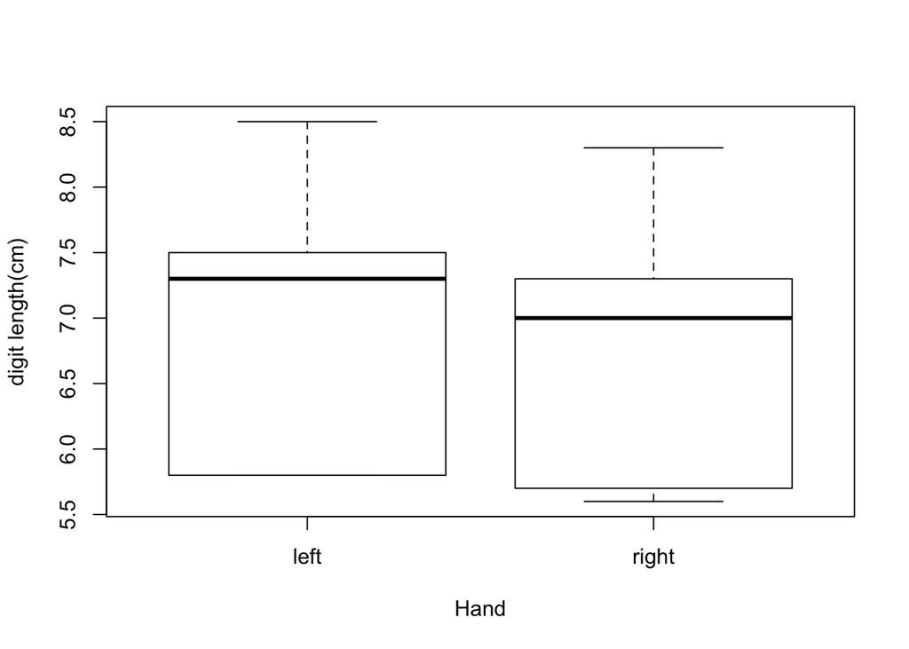

```r
boxplot(mydata$finger.length~mydata$hand, xlab="Hand", ylab="digit length(cm)")
```

There are few questions you have to ask yourself:

1. If the variances between left and right hand different?
2. If the data and errors are normally distributed?
3. If the data are dependent or independent?

To answer first questions we could perform var.test as follows:

```r
var.test(mydata$finger.length~mydata$hand)
```

```
##
##  F test to compare two variances
##
## data:  mydata$finger.length by mydata$hand
## F = 1.054, num df = 4, denom df = 4, p-value = 0.9606
## alternative hypothesis: true ratio of variances is not equal to 1
## 95 percent confidence interval:
##   0.1097368 10.1228931
## sample estimates:
## ratio of variances
##           1.053971
```

Answer: Since p-value is not lower than 0.05 there are no differences in variances between left and right hand.

To see actual differences we could make a barplot:

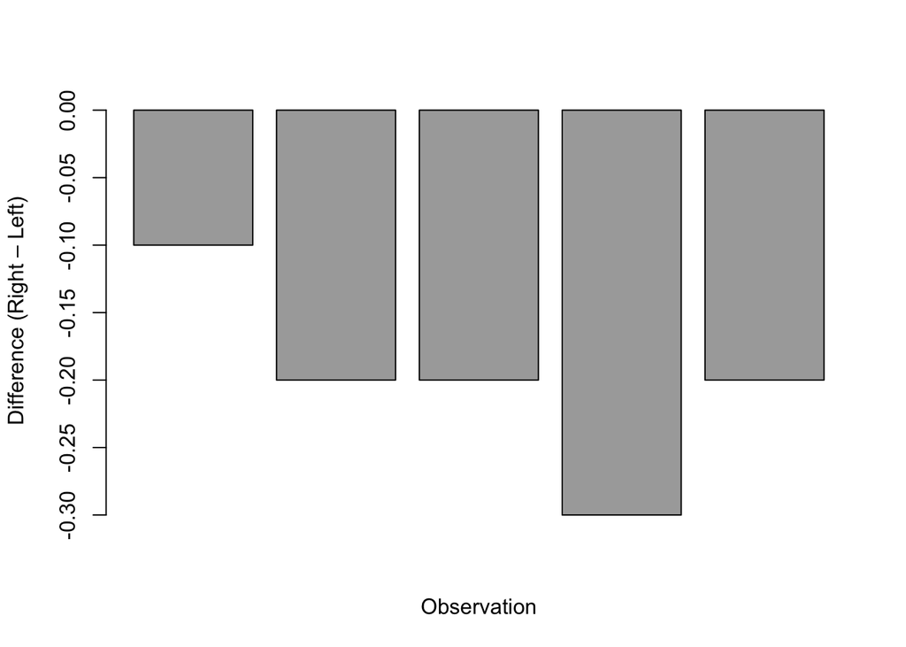

```r
Left_hand  = mydata$finger.length[mydata$hand=="left"]

Right_hand = mydata$finger.length[mydata$hand=="right"]

Difference = Right_hand - Left_hand

barplot(Difference,
        col="dark gray",
        xlab="Observation",
        ylab="Difference (Right – Left)")
```

However, if we had different variances we could use defalut t-test with default option var.equal = FALSE.

```r
welch.test <- t.test(mydata$finger.length~mydata$hand)
#or
welch.test.alternative <- t.test(mydata$finger.length[mydata$hand=="left"],mydata$finger.length[mydata$hand=="right"])
welch.test
```

```
##
##  Welch Two Sample t-test
##
## data:  mydata$finger.length by mydata$hand
## t = 0.274, df = 7.9945, p-value = 0.791
## alternative hypothesis: true difference in means is not equal to 0
## 95 percent confidence interval:
##  -1.483427  1.883427
## sample estimates:
##  mean in group left mean in group right
##                6.98                6.78
```

```r
welch.test.alternative
```

```
##
##  Welch Two Sample t-test
##
## data:  mydata$finger.length[mydata$hand == "left"] and mydata$finger.length[mydata$hand == "right"]
## t = 0.274, df = 7.9945, p-value = 0.791
## alternative hypothesis: true difference in means is not equal to 0
## 95 percent confidence interval:
##  -1.483427  1.883427
## sample estimates:
## mean of x mean of y
##      6.98      6.78
```

For more detils read following article:

Ruxton, G.D. (2006) The unequal variance t-test is an underused alternative to Student’s t-test and the Mann–Whitney U test. Behavioral Ecology, 17, 688-690.http://dx.doi.org/10.1093/beheco/ark016

We could conclude that there is no difference between right and left hand. However, we would see that this is WRONG!

# 5 T-test for normally distributed data and errors

We can perform two test depending on the fact that data and errors are normally distributed with the “classic” t-test.

```r
classic.test <- t.test(mydata$finger.length~mydata$hand, var.equal=T) #note that variances equality is true!
classic.test
```

```
##
##  Two Sample t-test
##
## data:  mydata$finger.length by mydata$hand
## t = 0.274, df = 8, p-value = 0.791
## alternative hypothesis: true difference in means is not equal to 0
## 95 percent confidence interval:
##  -1.483225  1.883225
## sample estimates:
##  mean in group left mean in group right
##                6.98                6.78
```

We can obresrve similar results like in the Welch test.

# 6 Paired T-test for normally distributed data and errors

```r
paired.test <- t.test(mydata$finger.length~mydata$hand, paired=T)
paired.test
```

```
##
##  Paired t-test
##
## data:  mydata$finger.length by mydata$hand
## t = 6.3246, df = 4, p-value = 0.003198
## alternative hypothesis: true difference in means is not equal to 0
## 95 percent confidence interval:
##  0.1122011 0.2877989
## sample estimates:
## mean of the differences
##                     0.2
```

And now something completely different!

Why?

We would suspect that someone with a large left hand is likely to have a large right hand. This means that measuring hands on the same individual leads to PAIRED observations. Basically this test shows that left hand fingers are longer that fingers on my left hand!

# 7 Non-parametric Mann-Whitney U-test for completeness

At the end if we have data that are not normally distributed than we could use this test. This test is called the “Wilcoxon Rank Sum (for non-paired data) and Signed Rank Tests (for paired data)” in R

First one with not paired observations.

```r
mann.test <- wilcox.test(mydata$finger.length~mydata$hand, paired=F)
mann.test
```

```
##
##  Wilcoxon rank sum test with continuity correction
##
## data:  mydata$finger.length by mydata$hand
## W = 16.5, p-value = 0.462
## alternative hypothesis: true location shift is not equal to 0
```

and for paired observations.

```r
signed.rank.test <- wilcox.test(mydata$finger.length~mydata$hand, paired=T)
signed.rank.test
```

```
##
##  Wilcoxon signed rank test with continuity correction
##
## data:  mydata$finger.length by mydata$hand
## V = 15, p-value = 0.05791
## alternative hypothesis: true location shift is not equal to 0
```

At the end to conclude: To see if your hand fingers are different we would use paired t-test while observations are measured on the same individual and since we assume normality of data distribution we would used classical paired parametric test which showed that fingers on my left hand are longer than fingers on my right hand.

# 8 ASSIGNMENT:

Measure your left and right finger length and test if there are some differences between your hands.